# R Notebook

Emmanuel Czar B. Pascua

# **IBM HR Analysis**

#### A data exploration case study

#### **First, let’s install some useful packages**

```r
install.packages("tidyverse")
install.packages("janitor")
install.packages("here")
install.packages("skimr")
library(tidyverse)
library(janitor)
library(here)
library(skimr)
```

#### **Let’s now load our downloaded csv file from kaggle.com**

```r
setwd("D:/FILES/DATA ANALYTICS/PORTFOLIO/IBM HR analytics")
ibm_hr <- read_csv("HR_Employee_Attrition.csv")
head(ibm_hr)
```

| Age | Attrition | BusinessTravel | DailyRate | Department | DistanceFromHome | Education | EducationField | EmployeeCount | EmployeeNumber | EnvironmentSatisfaction | Gender | HourlyRate | JobInvolvement | JobLevel | JobRole | JobSatisfaction | MaritalStatus | MonthlyIncome | MonthlyRate | NumCompaniesWorked | Over18 | OverTime | PercentSalaryHike | PerformanceRating | RelationshipSatisfaction | StandardHours | StockOptionLevel | TotalWorkingYears | TrainingTimesLastYear | … |
| --- | --- | --- | --- | --- | --- | --- | --- | --- | --- | --- | --- | --- | --- | --- | --- | --- | --- | --- | --- | --- | --- | --- | --- | --- | --- | --- | --- | --- | --- | --- |
| 41 | Yes | Travel_Rarely | 1102 | Sales | 1 | 2 | Life Sciences | 1 | 1 | 2 | Female | 94 | 3 | 2 | Sales Executive | 4 | Single | 5993 | 19479 | 8 | Y | Yes | 11 | 3 | 1 | 80 | 0 | 8 | 0 | … |
| 49 | No | Travel_Frequently | 279 | Research & Development | 8 | 1 | Life Sciences | 1 | 2 | 3 | Male | 61 | 2 | 2 | Research Scientist | 2 | Married | 5130 | 24907 | 1 | Y | No | 23 | 4 | 4 | 80 | 1 | 10 | 3 | … |
| 37 | Yes | Travel_Rarely | 1373 | Research & Development | 2 | 2 | Other | 1 | 4 | 4 | Male | 92 | 2 | 1 | Laboratory Technician | 3 | Single | 2090 | 2396 | 6 | Y | Yes | 15 | 3 | 2 | 80 | 0 | 7 | 3 | … |
| 33 | No | Travel_Frequently | 1392 | Research & Development | 3 | 4 | Life Sciences | 1 | 5 | 4 | Female | 56 | 3 | 1 | Research Scientist | 3 | Married | 2909 | 23159 | 1 | Y | Yes | 11 | 3 | 3 | 80 | 0 | 8 | 3 | … |
| 27 | No | Travel_Rarely | 591 | Research & Development | 2 | 1 | Medical | 1 | 7 | 1 | Male | 40 | 3 | 1 | Laboratory Technician | 2 | Married | 3468 | 16632 | 9 | Y | No | 12 | 3 | 4 | 80 | 1 | 6 | 3 | … |
| 32 | No | Travel_Frequently | 1005 | Research & Development | 2 | 2 | Life Sciences | 1 | 8 | 4 | Male | 79 | 3 | 1 | Laboratory Technician | 4 | Single | 3068 | 11864 | 0 | Y | No | 13 | 3 | 3 | 80 | 0 | 8 | 2 | … |

#### **Let’s now clean our data.**

Check for duplicates. This code will return True if unique employee numbers are equal to total number of rows

```r
length(unique(ibm_hr$EmployeeNumber)) == nrow(ibm_hr)
```

```
[1] TRUE
```

Check for missing values

```r
valmissing <- na.omit(ibm_hr)

if(nrow(valmissing) == nrow(ibm_hr)){
print("There are 0 missing values in the data")
}
```

```
[1] "There are 0 missing values in the data"
```

It looks like we don’t have null values since we still have the original number of rows.

#### **Find correlation**

Try to find correlation in our data set but first we have to drop non-numeric columns including arbitrary and non ordinal data such as EmployeeNumber and EmployeeCount.

```r
ibm_hr_num <- ibm_hr[sapply(ibm_hr, is.numeric)]

ibm_hr_nl <- subset(ibm_hr_num, select = -c(EmployeeNumber,EmployeeCount))
head(ibm_hr_nl)
```

| Age | DailyRate | DistanceFromHome | Education | EnvironmentSatisfaction | HourlyRate | JobInvolvement | JobLevel | JobSatisfaction | MonthlyIncome | MonthlyRate | NumCompaniesWorked | PercentSalaryHike | PerformanceRating | RelationshipSatisfaction | StandardHours | StockOptionLevel | TotalWorkingYears | TrainingTimesLastYear | WorkLifeBalance | YearsAtCompany | YearsInCurrentRole | YearsSinceLastPromotion | YearsWithCurrManager |
| --- | --- | --- | --- | --- | --- | --- | --- | --- | --- | --- | --- | --- | --- | --- | --- | --- | --- | --- | --- | --- | --- | --- | --- |
| 41 | 1102 | 1 | 2 | 2 | 94 | 3 | 2 | 4 | 5993 | 19479 | 8 | 11 | 3 | 1 | 80 | 0 | 8 | 0 | 1 | 6 | 4 | 0 | 5 |
| 49 | 279 | 8 | 1 | 3 | 61 | 2 | 2 | 2 | 5130 | 24907 | 1 | 23 | 4 | 4 | 80 | 1 | 10 | 3 | 3 | 10 | 7 | 1 | 7 |
| 37 | 1373 | 2 | 2 | 4 | 92 | 2 | 1 | 3 | 2090 | 2396 | 6 | 15 | 3 | 2 | 80 | 0 | 7 | 3 | 3 | 0 | 0 | 0 | 0 |
| 33 | 1392 | 3 | 4 | 4 | 56 | 3 | 1 | 3 | 2909 | 23159 | 1 | 11 | 3 | 3 | 80 | 0 | 8 | 3 | 3 | 8 | 7 | 3 | 0 |
| 27 | 591 | 2 | 1 | 1 | 40 | 3 | 1 | 2 | 3468 | 16632 | 9 | 12 | 3 | 4 | 80 | 1 | 6 | 3 | 3 | 2 | 2 | 2 | 2 |
| 32 | 1005 | 2 | 2 | 4 | 79 | 3 | 1 | 4 | 3068 | 11864 | 0 | 13 | 3 | 3 | 80 | 0 | 8 | 2 | 2 | 7 | 7 | 3 | 6 |

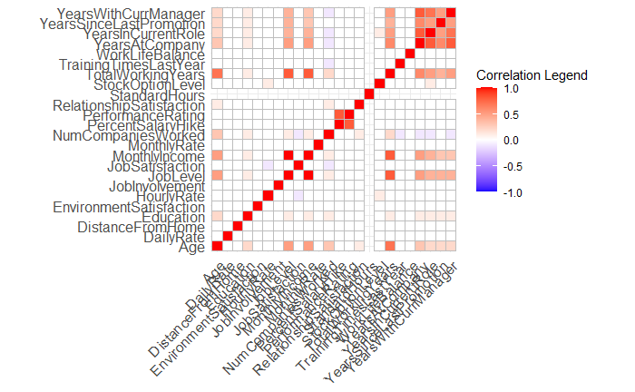

```r
install.packages("ggcorrplot")
library(ggcorrplot)
data(ibm_hr_nl)
corr <- round(cor(ibm_hr_nl), 1)
ggcorrplot(corr, legend.title = "Correlation Legend")
```

#### **Let’s now use ggplot2 package for the visualization to check for attrition rate across different variables**

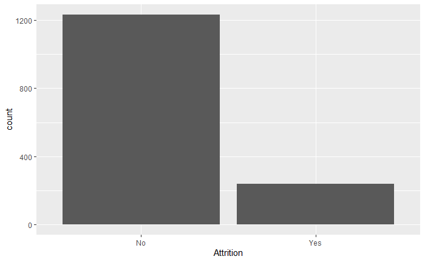

```r
ggplot(ibm_hr, aes(x = Attrition)) +
  geom_bar()
```

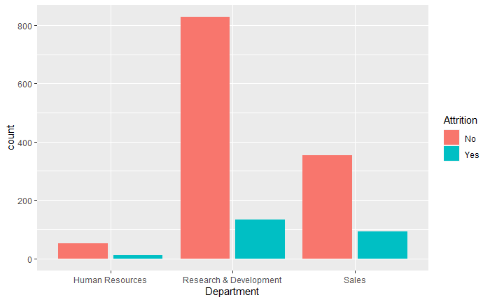

```r
#Generate visuals to compare attrition using different variables
ggplot(ibm_hr, aes(Department, fill=Attrition))+ geom_bar(position="dodge2")
```

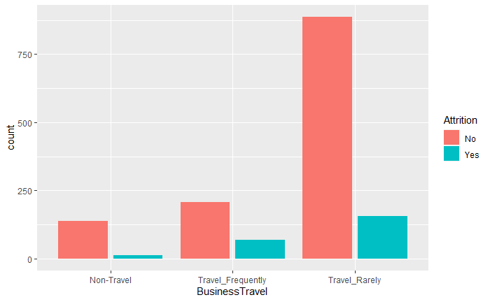

```r
ggplot(ibm_hr, aes(BusinessTravel, fill=Attrition))+ geom_bar(position="dodge2")
```

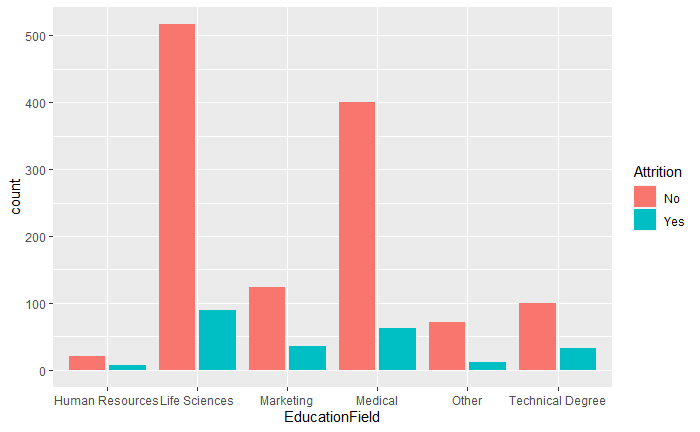

```r
ggplot(ibm_hr, aes(EducationField, fill=Attrition))+ geom_bar(position="dodge2")
```

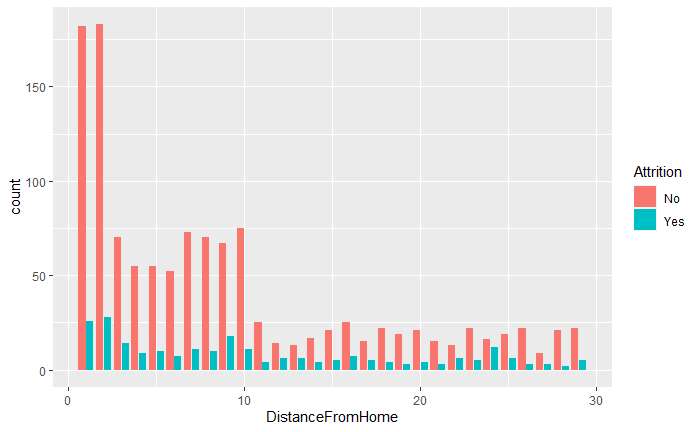

```r
ggplot(ibm_hr, aes(DistanceFromHome, fill=Attrition))+ geom_bar(position="dodge2")
```

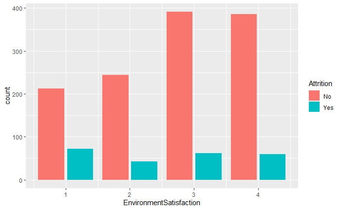

```r
ggplot(ibm_hr, aes(EnvironmentSatisfaction, fill=Attrition))+ geom_bar(position="dodge2")
```

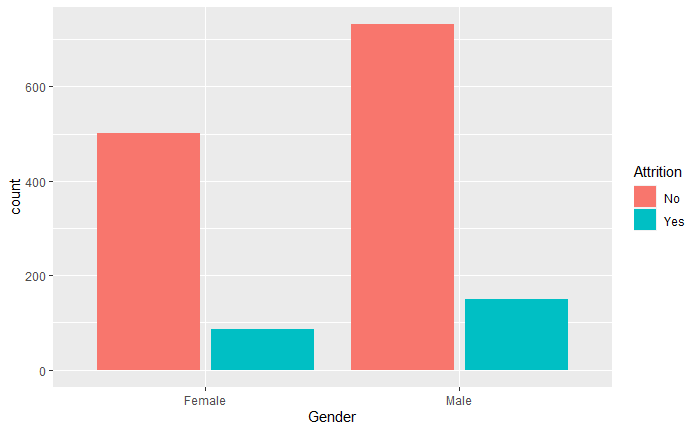

```r
ggplot(ibm_hr, aes(Gender, fill=Attrition))+ geom_bar(position="dodge2")
```

#### **Some observations on the visuals**

1. *Department* : Highest attrition in R&D, lowest in HR.
2. *Business Travel*: Highest attrition are those who travel rarely
3. *Education Field*: Highest attrition rate are those in life sciences but could be because LS make up majority of all employees.
4. *Distance from home*: no observed trend
5. *Environment satisfaction*: as expected, highest number of attrition came from those who rated poorly
6. *Gender*: Male employees left the make up the majority of the attrition count but could be because male dominates the majority of the total sample